Los datos que se muestran a continuaci ́on se hallan en el archivo buffalo.txt y correspon- den a la mediciones de cantidad de nieve ca ́ıda (en pulgadas) en Buffalo en los inviernos de

1910/1911 a 1972/1973.

```r
datos <- scan('./buffalo.txt')
```

# $$\huge \mathcal 1.$$

1. Realice un histograma para estos datos utilizando los par ́ametros por default. Repetir eligiendo como puntos de corte las siguientes secuencias: i) de 20 a 140 con paso 10 y ii) de 20 a 140 con paso 5. Comparar los tres histogramas obtenidos. ¿Tiene alg ́un efecto el refinamiento de los bins?

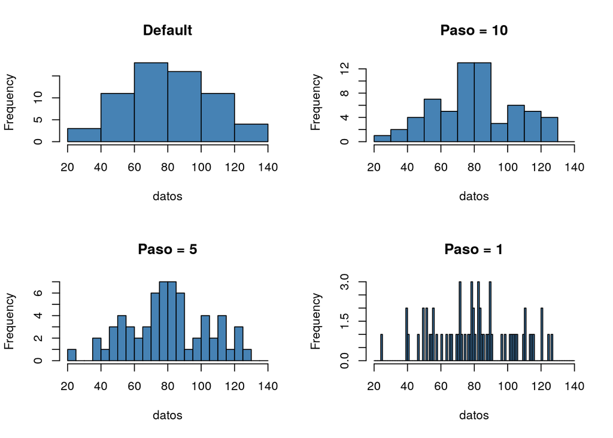

```r
par(mfrow=c(2,2))
hist(datos, col='steelblue',main="Default")
hist(datos, col='steelblue', breaks=seq(20,140,10),main="Paso = 10")
hist(datos, col='steelblue', breaks=seq(20,140,5),main="Paso = 5")
hist(datos, col='steelblue', breaks=seq(20,140,1),main="Paso = 1")
```

# $$\huge \mathcal 2.$$

2. Realice un histograma para estas observaciones utilizando puntos de corte (10, 20, 30, 40, 50, 60, 70, 80, 90, 100, 110, 120, 130). Repita corriendo el punto de inicio de los bins en 2 unidades 2 veces consecutivas. Compare los tres histogramas obtenidos. ¿Tiene alg ́un efecto la elecci ́on del punto inicial en este ejemplo?

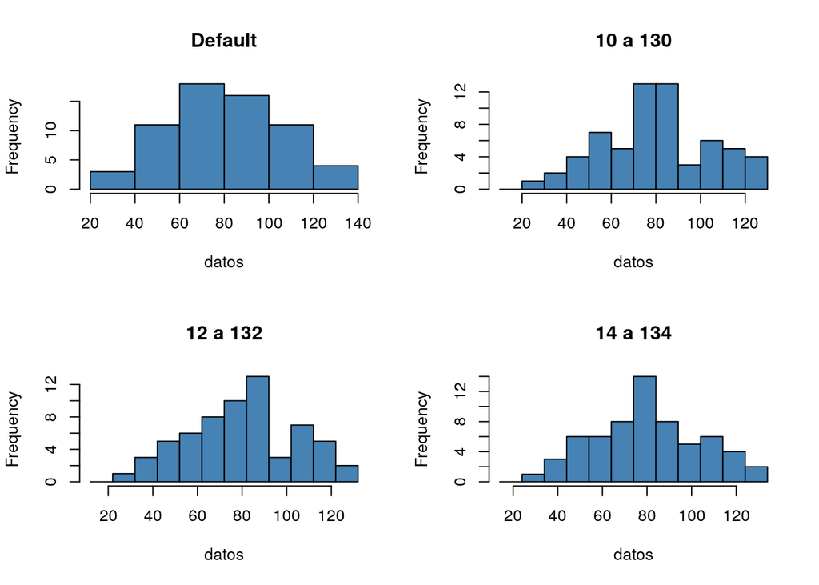

```r
par(mfrow=c(2,2))
hist(datos, col='steelblue',main="Default")
hist(datos, col='steelblue', breaks=seq(10,130,10),main="10 a 130")
hist(datos, col='steelblue', breaks=seq(12,132,10),main="12 a 132")
hist(datos, col='steelblue', breaks=seq(14,134,10),main="14 a 134")
```

# $$\huge \mathcal 3.$$

3. Implemente una funci ́on densidad.est.parzen que tenga por argumento un conjunto de datos x = (x1, . . . , xn), una ventana h y un punto x y devuelva fbh(x), el valor de la estimaci ́on de la densidad f en el punto x, utilizando el n ́ucleo uniforme (tambi ́en llamado rectangular).

## Estimador de Parzen

> $$\large \hat f_h(z) = \frac 1 {n h} \sum_{i=1}^n \mathbf K \left( \frac {z - X_i}{h} \right)$$

donde

Es el kernel uniforme $[-1,1]$ (aka núcleo rectangular)

```r
densidad.est.parzen <- function(X, h, z){
    n <- length(X)
    t <- (z - X) / h
    Kt <- 0.5 * (t > -1 & t < 1)

    fhz <- 1 / (n*h) * sum(Kt)

    return(fhz)
}
```

# $$\huge \mathcal 4.$$

4. Con la funci ́on densidad.est.parzen implementada, estime la densidad f en el inter- valo (25,126.4) (m ́ınimo y m ́aximo de las observaciones) sobre una grilla de 200 puntos

equiespaciados para h = 10. Grafique el estimador fbh(x) obtenido.

```r
Ngrilla <- 200
grilla.z <- seq(min(datos), max(datos), length=Ngrilla)
```

```r
h.10  <- 10
h.05 <- 0.5
h.2  <- 2
f_hat.10  <- rep(NA, Ngrilla)
f_hat.05 <- rep(NA, Ngrilla)
f_hat.2  <- rep(NA, Ngrilla)
for(i in 1:Ngrilla){
    f_hat.10[i]   <- densidad.est.parzen(datos, h.10, grilla.z[i])
    f_hat.05[i]  <- densidad.est.parzen(datos, h.05, grilla.z[i])
    f_hat.2[i]   <- densidad.est.parzen(datos, h.2, grilla.z[i])
}
```

```r
#?plotmath
```

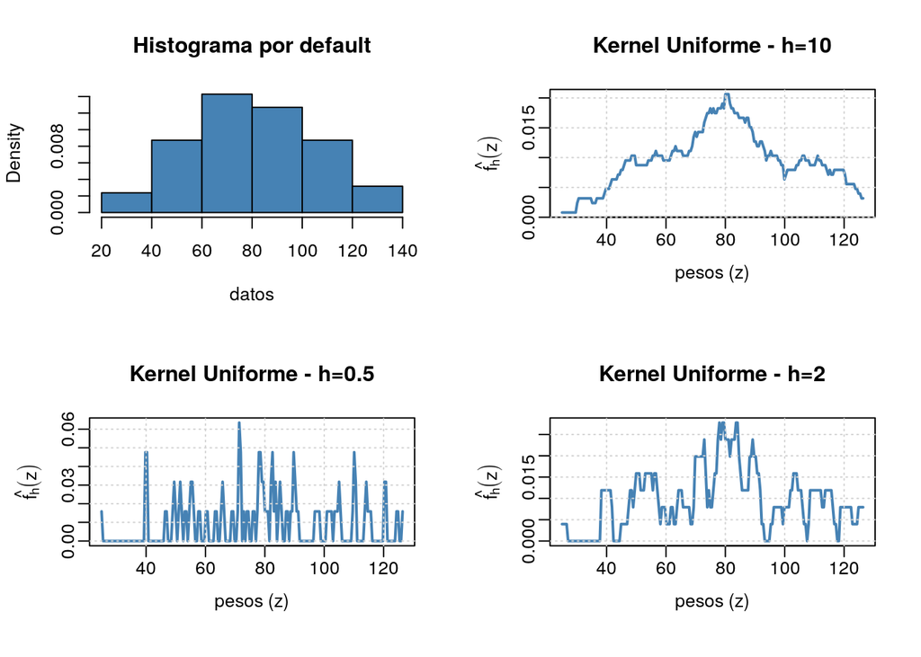

```r
par(mfrow=c(2,2))
hist(datos, col="steelblue", prob=T, main="Histograma por default")
plot(grilla.z, f_hat.10, type='l', col='steelblue', lwd=2,main = "Kernel Uniforme - h=10", xlab='pesos (z)', ylab=expression(hat(f[h])(z)), mgp=c(2,0.5,0))
grid()
plot(grilla.z, f_hat.05, type='l', col='steelblue', lwd=2,main = "Kernel Uniforme - h=0.5", xlab='pesos (z)', ylab=expression(hat(f[h])(z)), mgp=c(2,0.5,0))
grid()
plot(grilla.z, f_hat.2, type='l', col='steelblue', lwd=2,main = "Kernel Uniforme - h=2", xlab='pesos (z)', ylab=expression(hat(f[h])(z)), mgp=c(2,0.5,0))
grid()
```

# $$\huge \mathcal 5.$$

5. Estime la funci ́on de densidad f de la variable pulgadas de nieve ca ́ıda en invierno a partir de los datos de Buffalo a trav ́es de la funci ́on densidad.est.parzen implementada en el item anterior usando h = 10. Realice un histograma para los datos de Buffalo y superponga la densidad estimada en los datos mediante la funci ́on densidad.est.parzen utilizando h = 10, 20 y 30. Observe como var ́ıa la rugosidad de los estimadores de f obtenidos.

```r
h.10 <- 10
h.20 <- 20
h.30 <- 30
f_hat.10 <- rep(NA, Ngrilla)
f_hat.20 <- rep(NA, Ngrilla)
f_hat.30 <- rep(NA, Ngrilla)
for(i in 1:Ngrilla){
    f_hat.10[i]  <- densidad.est.parzen(datos, h.10, grilla.z[i])
    f_hat.20[i]  <- densidad.est.parzen(datos, h.20, grilla.z[i])
    f_hat.30[i]  <- densidad.est.parzen(datos, h.30, grilla.z[i])
}
```

```r
#?plotmath
```

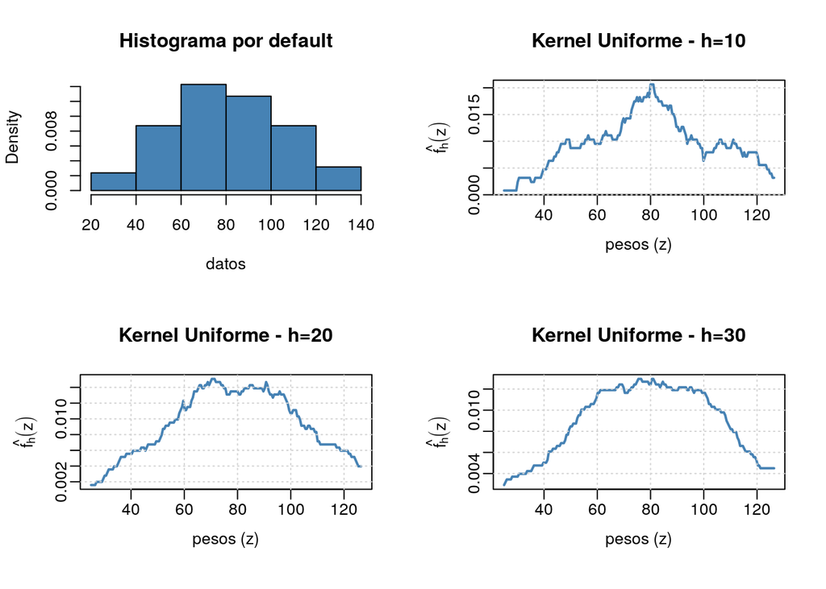

```r
par(mfrow=c(2,2))
hist(datos, col="steelblue", prob=T, main="Histograma por default")
plot(grilla.z, f_hat.10, type='l', col='steelblue', lwd=2,main = "Kernel Uniforme - h=10", xlab='pesos (z)', ylab=expression(hat(f[h])(z)), mgp=c(2,0.5,0))
grid()
plot(grilla.z, f_hat.20, type='l', col='steelblue', lwd=2,main = "Kernel Uniforme - h=20", xlab='pesos (z)', ylab=expression(hat(f[h])(z)), mgp=c(2,0.5,0))
grid()
plot(grilla.z, f_hat.30, type='l', col='steelblue', lwd=2,main = "Kernel Uniforme - h=30", xlab='pesos (z)', ylab=expression(hat(f[h])(z)), mgp=c(2,0.5,0))
grid()
```

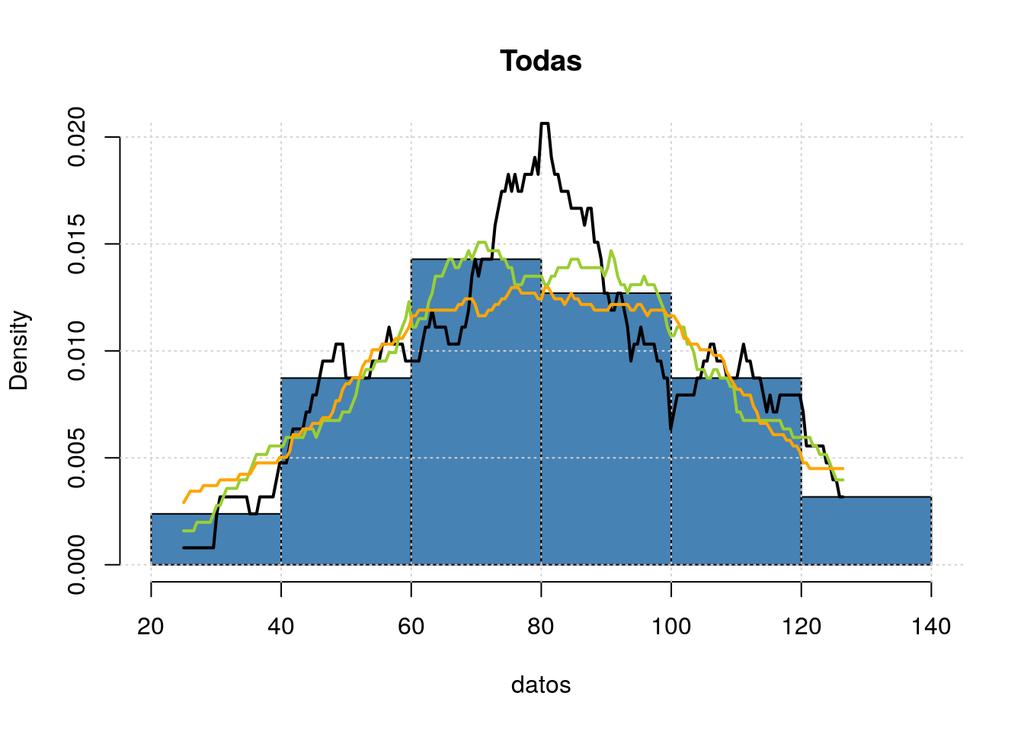

```r
hist(datos, col="steelblue", prob=T, main="Todas", ylim=c(0, 0.02))
grid()
lines(grilla.z, f_hat.10, type='l', col='black', lwd=2,
      main = "Kernel Uniforme - h=10", xlab='pesos (z)', ylab=expression(hat(f[h])(z)), mgp=c(2,0.5,0))
lines(grilla.z, f_hat.20, type='l', col='yellowgreen', lwd=2,main = "Kernel Uniforme - h=20", xlab='pesos (z)', ylab=expression(hat(f[h])(z)), mgp=c(2,0.5,0))
lines(grilla.z, f_hat.30, type='l', col='orange', lwd=2,main = "Kernel Uniforme - h=30", xlab='pesos (z)', ylab=expression(hat(f[h])(z)), mgp=c(2,0.5,0))
```

```r
density(datos, kernel='rectangular', window=10)
```

```
##
## Call:
##  density.default(x = datos, kernel = "rectangular", window = 10)
##
## Data: datos (63 obs.);   Bandwidth 'bw' = 9.321
##
##        x                 y
##  Min.   : -2.964   Min.   :0.0000000
##  1st Qu.: 36.368   1st Qu.:0.0004916
##  Median : 75.700   Median :0.0062270
##  Mean   : 75.700   Mean   :0.0063298
##  3rd Qu.:115.032   3rd Qu.:0.0106396
##  Max.   :154.364   Max.   :0.0157302
```

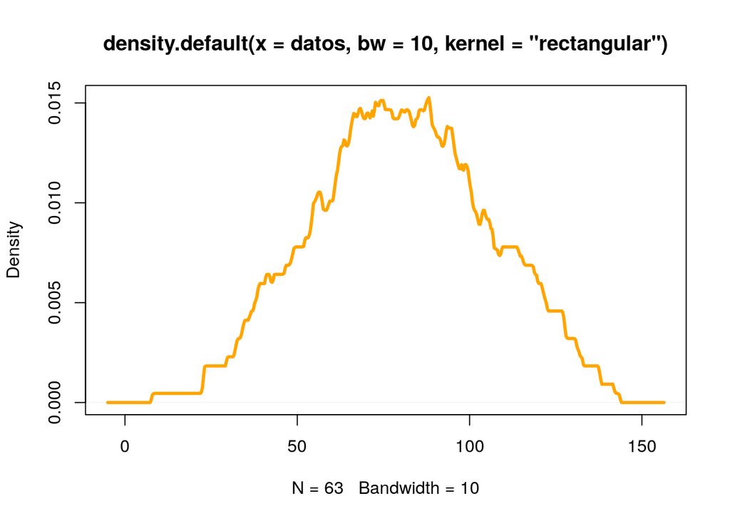

```r
plot(density(datos, kernel='rectangular', bw=10), lwd=3, col="orange")
```

# $$\huge \mathcal 6.$$

6. La funci ́on de R density computa un estimador de la densidad a partir de un conjunto de datos x = (x1, . . . , xn) y la eval ́ua en un conjunto de puntos intermedios.

Mediante la funci ́on de R density estime la funci ́on de densidad f de la variable pulgadas de nieve ca ́ıda en invierno a partir de los datos de Buffalo y utilizando el **nucleo normal, el rectangular y el de Epanechnikov** con ventana h = 5.

Realice un gr ́afico en el que superpone las tres estimaciones de f y compare los resultados.

> Agrego el **triangular** porque está en las diapos y me parece interesante, ya que da pesos que decaen linealmente con la distancia al centro.

> Implemento nucleos porque sí.

$$\begin{align}
\large \textbf{Rectangular} : K(t) & \large \ = \frac 1 2 \mathbb 1_{[-1,1]}(t)\\\\
\large\textbf{Triangular} : K(t) & \large \ = (1-|t|) \mathbb 1_{[-1,1]}(t) \\\\
\large\textbf{Gaussiano} : K(t) & \large \ = \frac 1 {\sqrt{2\pi}} e^{-\frac 1 2 t^2} \\\\
\large\textbf{Epanechnikov} : K(t) & \large \ = \frac 3 4 (1-t^2) 1_{[-1,1]}(t) \\\\
\end{align}$$

```r
ker.uniforme <- function(t){
    return (0.5 * (t > -1 & t < 1))
}
```

```r
ker.triangular <- function(t){
    return ((1-abs(t)) * (t > -1 & t < 1))
}
```

```r
ker.gaussiano <- function(t){
    return (dnorm(t, mean=0, sd=1))
}
```

```r
ker.epanechnikov <- function(t){
    return (3/4 * (1-t^2) * (t > -1 & t < 1))
}
```

```r
Ngrilla  <- 200
grilla.z <- seq(-1.5, 1.5, length=Ngrilla)
```

```r
f.uni <- rep(NA, Ngrilla)
f.tri <- rep(NA, Ngrilla)
f.gau <- rep(NA, Ngrilla)
f.epa <- rep(NA, Ngrilla)
for(i in 1:Ngrilla){
    t <- grilla.z[i]
    f.uni[i]  <- ker.uniforme(t)
    f.tri[i]  <- ker.triangular(t)
    f.gau[i]  <- ker.gaussiano(t)
    f.epa[i]  <- ker.epanechnikov(t)
}
```

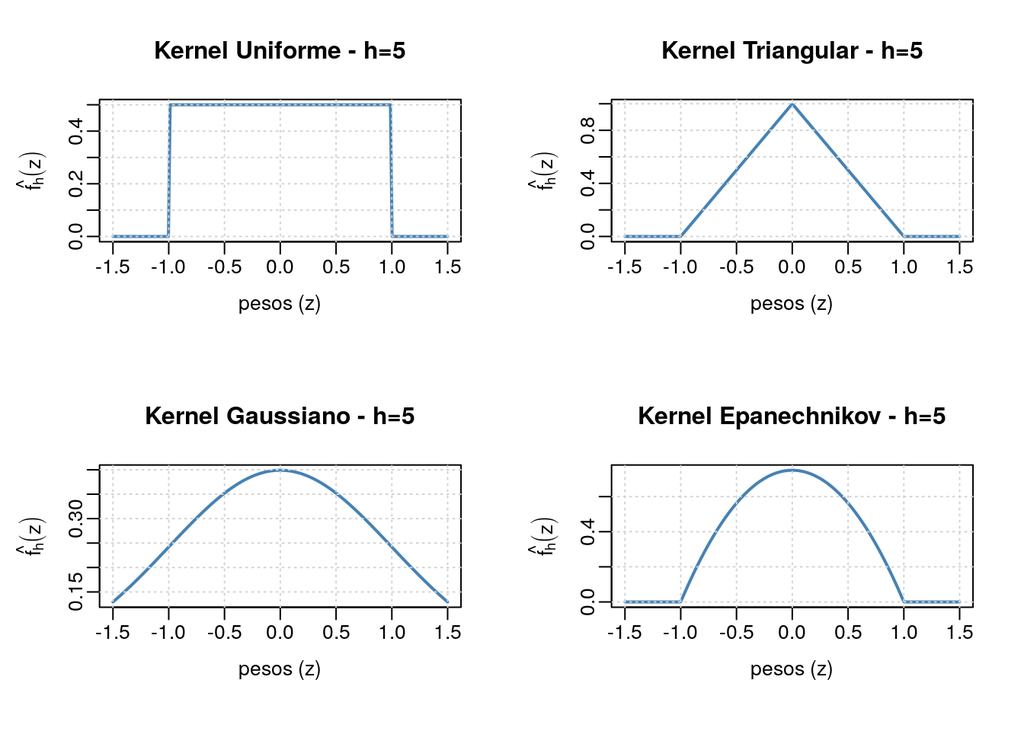

```r
par(mfrow=c(2,2))
plot(grilla.z, f.uni, type='l', col='steelblue', lwd=2,main = "Kernel Uniforme - h=5", xlab='pesos (z)', ylab=expression(hat(f[h])(z)), mgp=c(2,0.5,0))
grid()
plot(grilla.z, f.tri, type='l', col='steelblue', lwd=2,main = "Kernel Triangular - h=5", xlab='pesos (z)', ylab=expression(hat(f[h])(z)), mgp=c(2,0.5,0))
grid()
plot(grilla.z, f.gau, type='l', col='steelblue', lwd=2,main = "Kernel Gaussiano - h=5", xlab='pesos (z)', ylab=expression(hat(f[h])(z)), mgp=c(2,0.5,0))
grid()
plot(grilla.z, f.epa, type='l', col='steelblue', lwd=2,main = "Kernel Epanechnikov - h=5", xlab='pesos (z)', ylab=expression(hat(f[h])(z)), mgp=c(2,0.5,0))
grid()
```

```r
densidad.est.parzen.ker <- function(X, h, z, K){
    n <- length(X)
    t <- (z - X) / h
    Kt <- K(t)

    fhz <- 1 / (n*h) * sum(Kt)

    return(fhz)
}
```

```r
Ngrilla <- 200
grilla.z <- seq(min(datos), max(datos), length=Ngrilla)
```

```r
h.5 <- 5
f_hat.uni <- rep(NA, Ngrilla)
f_hat.tri <- rep(NA, Ngrilla)
f_hat.gau <- rep(NA, Ngrilla)
f_hat.epa <- rep(NA, Ngrilla)
for(i in 1:Ngrilla){
    t <- grilla.z[i]
    f_hat.uni[i]  <- densidad.est.parzen.ker(datos, h.5, t, ker.uniforme)
    f_hat.tri[i]  <- densidad.est.parzen.ker(datos, h.5, t, ker.triangular)
    f_hat.gau[i]  <- densidad.est.parzen.ker(datos, h.5, t, ker.gaussiano)
    f_hat.epa[i]  <- densidad.est.parzen.ker(datos, h.5, t, ker.epanechnikov)
}
```

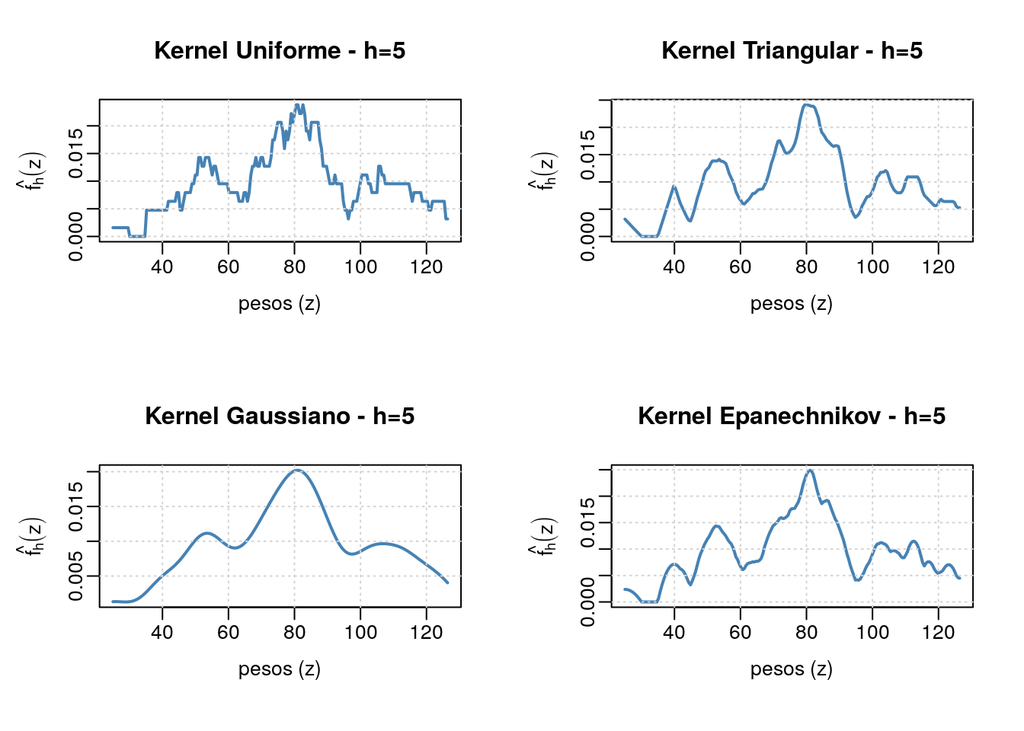

```r
par(mfrow=c(2,2))
plot(grilla.z, f_hat.uni, type='l', col='steelblue', lwd=2,main = "Kernel Uniforme - h=5", xlab='pesos (z)', ylab=expression(hat(f[h])(z)), mgp=c(2,0.5,0))
grid()
plot(grilla.z, f_hat.tri, type='l', col='steelblue', lwd=2,main = "Kernel Triangular - h=5", xlab='pesos (z)', ylab=expression(hat(f[h])(z)), mgp=c(2,0.5,0))
grid()
plot(grilla.z, f_hat.gau, type='l', col='steelblue', lwd=2,main = "Kernel Gaussiano - h=5", xlab='pesos (z)', ylab=expression(hat(f[h])(z)), mgp=c(2,0.5,0))
grid()
plot(grilla.z, f_hat.epa, type='l', col='steelblue', lwd=2,main = "Kernel Epanechnikov - h=5", xlab='pesos (z)', ylab=expression(hat(f[h])(z)), mgp=c(2,0.5,0))
grid()
```

```r
h.10 <- 10
f_hat.uni <- rep(NA, Ngrilla)
f_hat.tri <- rep(NA, Ngrilla)
f_hat.gau <- rep(NA, Ngrilla)
f_hat.epa <- rep(NA, Ngrilla)
for(i in 1:Ngrilla){
    t <- grilla.z[i]
    f_hat.uni[i]  <- densidad.est.parzen.ker(datos, h.10, t, ker.uniforme)
    f_hat.tri[i]  <- densidad.est.parzen.ker(datos, h.10, t, ker.triangular)
    f_hat.gau[i]  <- densidad.est.parzen.ker(datos, h.10, t, ker.gaussiano)
    f_hat.epa[i]  <- densidad.est.parzen.ker(datos, h.10, t, ker.epanechnikov)
}
```

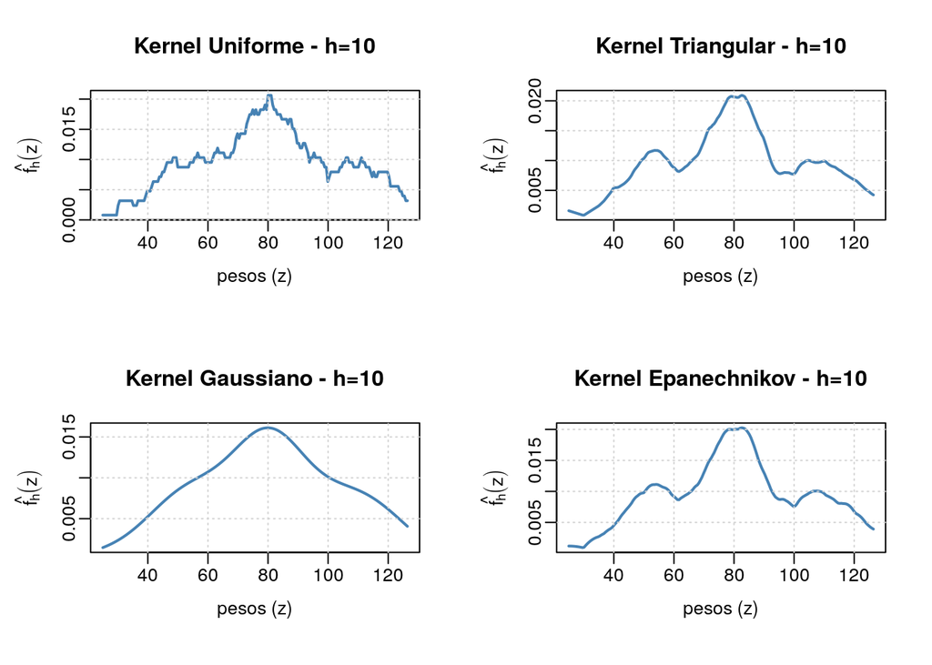

```r
par(mfrow=c(2,2))
plot(grilla.z, f_hat.uni, type='l', col='steelblue', lwd=2,main = "Kernel Uniforme - h=10", xlab='pesos (z)', ylab=expression(hat(f[h])(z)), mgp=c(2,0.5,0))
grid()
plot(grilla.z, f_hat.tri, type='l', col='steelblue', lwd=2,main = "Kernel Triangular - h=10", xlab='pesos (z)', ylab=expression(hat(f[h])(z)), mgp=c(2,0.5,0))
grid()
plot(grilla.z, f_hat.gau, type='l', col='steelblue', lwd=2,main = "Kernel Gaussiano - h=10", xlab='pesos (z)', ylab=expression(hat(f[h])(z)), mgp=c(2,0.5,0))
grid()
plot(grilla.z, f_hat.epa, type='l', col='steelblue', lwd=2,main = "Kernel Epanechnikov - h=10", xlab='pesos (z)', ylab=expression(hat(f[h])(z)), mgp=c(2,0.5,0))
grid()
```

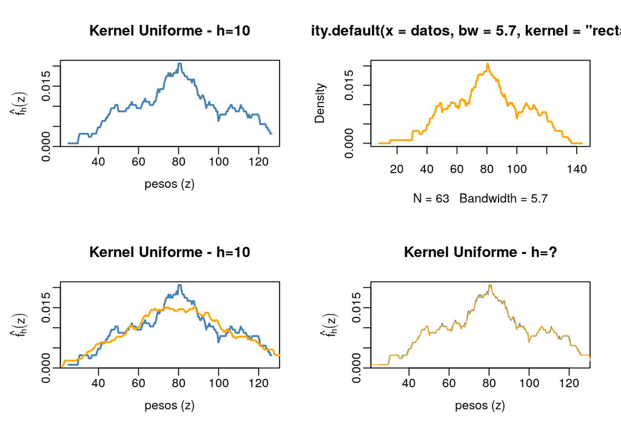

```r
par(mfrow=c(2,2))
plot(grilla.z, f_hat.uni, type='l', col='steelblue', lwd=2, main = "Kernel Uniforme - h=10", xlab='pesos (z)', ylab=expression(hat(f[h])(z)), mgp=c(2,0.5,0))
plot(density(datos, kernel='rectangular', bw=5.7), lwd=2, col='orange')

plot(grilla.z, f_hat.uni, type='l', col='steelblue', lwd=2, main = "Kernel Uniforme - h=10", xlab='pesos (z)', ylab=expression(hat(f[h])(z)), mgp=c(2,0.5,0))
lines(density(datos, kernel='rectangular', bw=10), lwd=2, col='orange')

plot(grilla.z, f_hat.uni, type='l', col='steelblue', lwd=1, main = "Kernel Uniforme - h=?", xlab='pesos (z)', ylab=expression(hat(f[h])(z)), mgp=c(2,0.5,0))
lines(density(datos, kernel='rectangular', bw=5.7), lwd=1, col='orange')
```

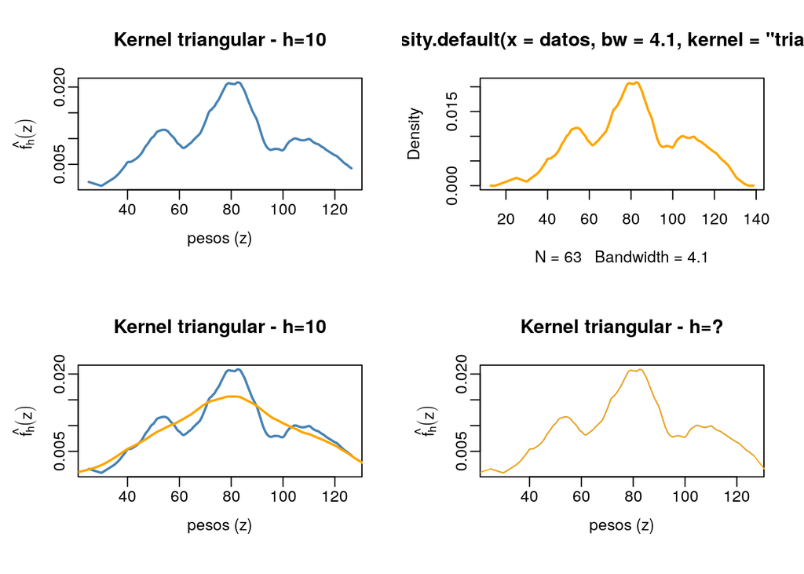

```r
par(mfrow=c(2,2))
plot(grilla.z, f_hat.tri, type='l', col='steelblue', lwd=2, main = "Kernel triangular - h=10", xlab='pesos (z)', ylab=expression(hat(f[h])(z)), mgp=c(2,0.5,0))

plot(density(datos, kernel='triangular', bw=4.1), lwd=2, col='orange')

plot(grilla.z, f_hat.tri, type='l', col='steelblue', lwd=2, main = "Kernel triangular - h=10", xlab='pesos (z)', ylab=expression(hat(f[h])(z)), mgp=c(2,0.5,0))
lines(density(datos, kernel='triangular', bw=10), lwd=2, col='orange')

plot(grilla.z, f_hat.tri, type='l', col='steelblue', lwd=1, main = "Kernel triangular - h=?", xlab='pesos (z)', ylab=expression(hat(f[h])(z)), mgp=c(2,0.5,0))
lines(density(datos, kernel='triangular', bw=4.1), lwd=1, col='orange')
```

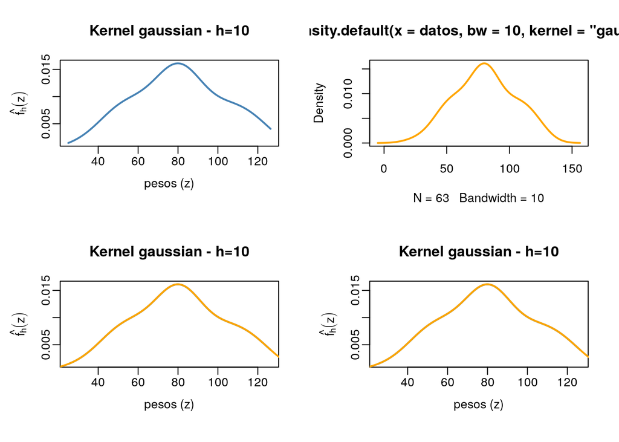

```r
par(mfrow=c(2,2))
plot(grilla.z, f_hat.gau, type='l', col='steelblue', lwd=2, main = "Kernel gaussian - h=10", xlab='pesos (z)', ylab=expression(hat(f[h])(z)), mgp=c(2,0.5,0))
plot(density(datos, kernel='gaussian', bw=10), lwd=2,col='orange')

plot(grilla.z, f_hat.gau, type='l', col='steelblue', lwd=2, main = "Kernel gaussian - h=10", xlab='pesos (z)', ylab=expression(hat(f[h])(z)), mgp=c(2,0.5,0))
lines(density(datos, kernel='gaussian', bw=10), lwd=2,col='orange')

plot(grilla.z, f_hat.gau, type='l', col='steelblue', lwd=2, main = "Kernel gaussian - h=10", xlab='pesos (z)', ylab=expression(hat(f[h])(z)), mgp=c(2,0.5,0))
lines(density(datos, kernel='gaussian', bw=10), lwd=2,col='orange')
```

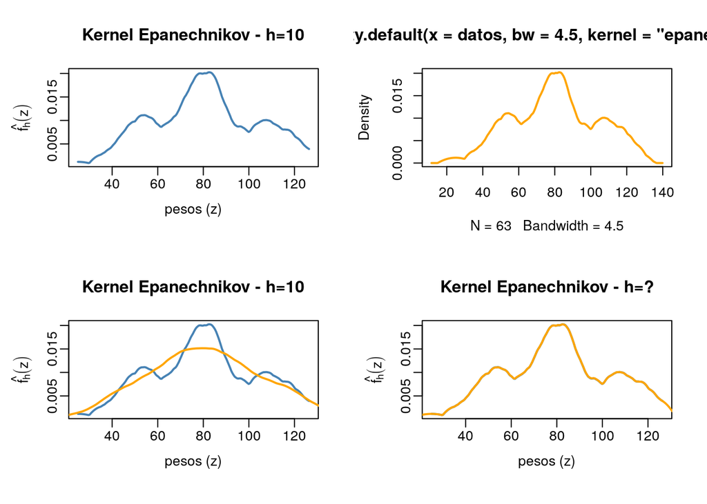

```r
par(mfrow=c(2,2))
plot(grilla.z, f_hat.epa, type='l', col='steelblue', lwd=2, main = "Kernel Epanechnikov - h=10", xlab='pesos (z)', ylab=expression(hat(f[h])(z)), mgp=c(2,0.5,0))
plot(density(datos, kernel='epanechnikov', bw=4.5), lwd=2,col='orange')

plot(grilla.z, f_hat.epa, type='l', col='steelblue', lwd=2, main = "Kernel Epanechnikov - h=10", xlab='pesos (z)', ylab=expression(hat(f[h])(z)), mgp=c(2,0.5,0))
lines(density(datos, kernel='epanechnikov', bw=10), lwd=2,col='orange')

plot(grilla.z, f_hat.epa, type='l', col='steelblue', lwd=2, main = "Kernel Epanechnikov - h=?", xlab='pesos (z)', ylab=expression(hat(f[h])(z)), mgp=c(2,0.5,0))
lines(density(datos, kernel='epanechnikov', bw=4.5), lwd=2,col='orange')
```